# Buró y test de bienestar financiero

Juan David Ospina Arango Líder Analítica qiip - www.qiip.com.co

4 de marzo de 2021

# Score de buró y test de bienestar financiero en qiip

**Objetivo**: explorar las relaciones que pueden existir entre el test de bienestar financiero y el score de buró.

## Materiales y métodos

### Materiales

Se analizaron 1239 usuarios qiip para los cuales se contaba con sus respuestas al test de bienestar financiero y la consulta a su historial crediticio desde qiip al 24 de enero de 2021.

Con respecto al test de bienstar financiero se extrajeron las siguientes variables:

- Máx. de score_qiip
- Máx. de estado_actual
- Máx. de acompanamiento
- Máx. de conciencia
- Máx. de planeacion
- Máx. de proteccion
- Máx. de relacion_con_el_dinero
- Máx. de soluciones

En este análisis no se consideran las respuestas individuuales a cada pregunta del test de bienestar, sino las agregaciones anteriores.

### Métodos

1. Análisis descriptivo: se obtendrán las medidas de tendencia central y de dispersión de las variables mencionadas y las correlaciones por pares.
2. Agrupamiento de los usuarios de acuerdo al test de bienestar: se usará el algoritmo de *K-Means* para agrupar a los usuarios de acuerdo a las respuestas del test de bienestar financiero. Se seleccionarán un número de grupos, $K$, de manera que estos sean interpretables y manejables. Se describirán los grupos en términos de sus medias y desviaciones estándares respecto a las preguntas del test de bienestar
3. Análisis del score de buró en cada grupo obtenido: se estudiará el comportamiento entre las respuestas del test de bienestar financiero y el score de buró al interior de cada grupo.

## Resultados

### Análisis descriptivo

A continuación se presentan los valores mínimos, el valor del primer cuartil, la mediana, la media, el tercer cuartil, el máximo y el número de valores faltantes (NAs) de cada variable considerada:

Primer cuartil (1st Qu), la mediana, la media, el tercer cuartil (3rd Qu), el máximo y el número de valores faltantes (NAs) de cada variable considerada

|  | Máx. de score | Máx. de score_qiip | Máx. de estado_actual | Máx. de acompanamiento | Máx. de conciencia | Máx. de planeacion | Máx. de proteccion | Máx. de relacion_con_el_dinero | Máx. de soluciones |
| --- | --- | --- | --- | --- | --- | --- | --- | --- | --- |
|  | Min. : 0.0 | Min. : 2.00 | Min. : 0.00 | Min. : 0.00 | Min. : 0.00 | Min. : 0.00 | Min. : 0.00 | Min. : 0.0 | Min. : 0.00 |
|  | 1st Qu.: 0.0 | 1st Qu.: 33.00 | 1st Qu.: 25.00 | 1st Qu.: 25.00 | 1st Qu.: 37.00 | 1st Qu.: 37.00 | 1st Qu.: 25.00 | 1st Qu.:33.0 | 1st Qu.: 0.00 |
|  | Median :565.0 | Median : 50.00 | Median : 50.00 | Median : 50.00 | Median : 50.00 | Median : 62.00 | Median : 37.00 | Median :45.0 | Median : 50.00 |
|  | Mean :446.3 | Mean : 49.91 | Mean : 47.22 | Mean : 45.11 | Mean : 54.29 | Mean : 59.04 | Mean : 45.42 | Mean :44.8 | Mean : 52.88 |
|  | 3rd Qu.:629.5 | 3rd Qu.: 66.00 | 3rd Qu.: 75.00 | 3rd Qu.: 62.00 | 3rd Qu.: 75.00 | 3rd Qu.: 75.00 | 3rd Qu.: 62.00 | 3rd Qu.:56.0 | 3rd Qu.:100.00 |
|  | Max. :724.0 | Max. :100.00 | Max. :100.00 | Max. :100.00 | Max. :100.00 | Max. :100.00 | Max. :100.00 | Max. :98.0 | Max. :100.00 |
|  | NA | NA’s :8 | NA’s :8 | NA’s :8 | NA’s :8 | NA’s :8 | NA’s :8 | NA’s :8 | NA’s :8 |

A continuación se presenta la desviación estándar de cada variable considerada:

Desviaciones estándar de las variables consideradas

| Máx. de score | Máx. de score_qiip | Máx. de estado_actual | Máx. de acompanamiento | Máx. de conciencia | Máx. de planeacion | Máx. de proteccion | Máx. de relacion_con_el_dinero | Máx. de soluciones |
| --- | --- | --- | --- | --- | --- | --- | --- | --- |
| 265.5 | 21.56 | 27.46 | 28.37 | 25.16 | 26.91 | 23.3 | 16.29 | 43.26 |

### El score de buró vs el score qiip

La siguiente figura muestra el score de buró (eje $y$) vs el score de qiip (eje $x$):

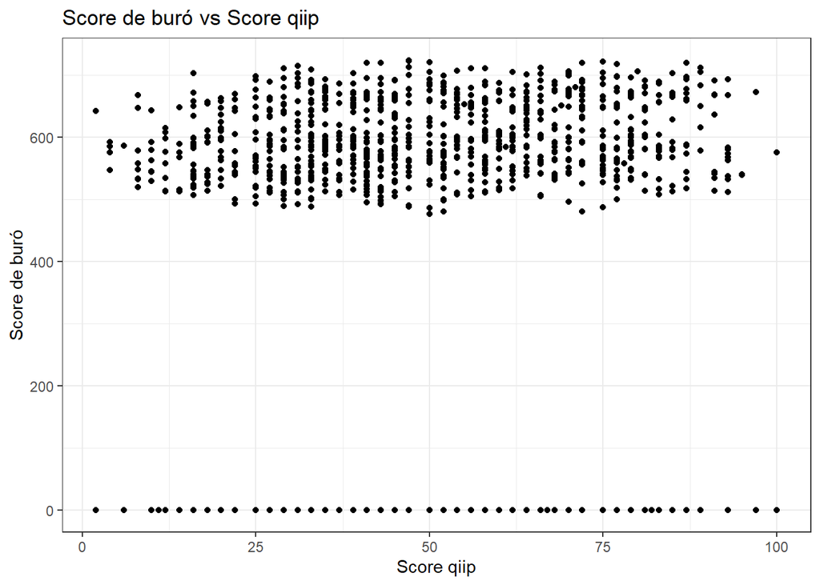

La correlación entre el score de buró y el score qiip es de 5.02%. Tanto la gráfica como el valor de correlación muestran que la asociación enntre ambas variables sobre toda la población es débil. Sin embargo, no se puede aún concluir que dicha asociación no exista, ya que puede estar enmascarada por otras variables de comportamiento o demográficas, no incluidas en este análisis.

La siguiente figura presenta la matriz de correlaciones entre las variables consideras en este análisis. La magnitud de las correlaciones se representa por el tamaña del círculo y la dirección por el color, como lo muestra la barra adyacente a la matriz:

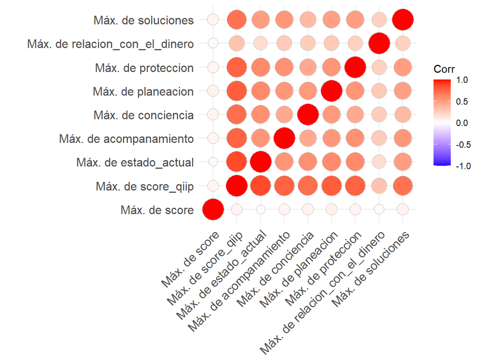

En esta gráfica se aprecia que: * El score de buró no está fuertemente correlacionado con las preguntas del test de bienestar financiero. * Las preguntas del test de bienestar están altamente correlacionadas entre sí, con excepción de aquellas relacionadas con la relación con el dinero.

La siguiente gráfica muestra las relaciones por pares entre las preguntas del test de bienestar financiero:

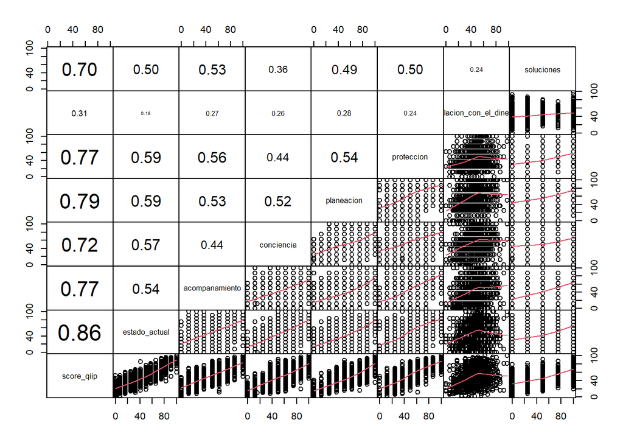

### Agrupamiento de los usuarios según el test de bienestar financiero

En este apartado se lleva acabo el agrupamiento con diferentes números de grupos.

La técnica seleccionada fue K-Means. Los resultados del test de bienestar financiero en cada dimensión, tienen la ventaja de estar en la misma escala, por lo que no se requiere un paso de escalamiento de los datos.

Se probaron diferentes números de centroides, $K$, desde 2 hasta 10. Esto con el objetivo de entender el poder discriminante de los grupo con un número reducido de los mismos. Para cada valor de $K$ se permitieron tres inicializaciones aleatorias de los centroides.

Para ilustrar el efecto del número de centroides se propone graficar los grupos usando solo dos dimensiones del test de bienestar financiero: la relación con el dinero y el estado actual.

La siguiente figura presenta los resultados obtenidos con $K=2,3,4,5$ grupos.

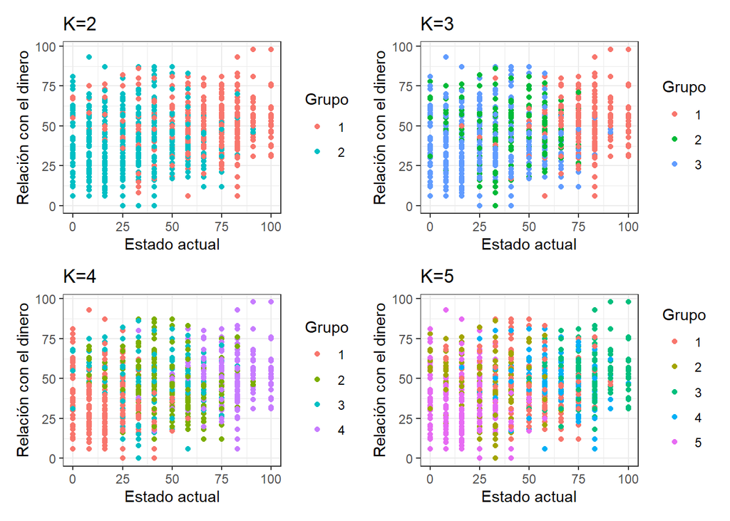

Se puede observar en la figura anterior, que para diferentes valores de $K$ hay consistencia en que hay al menos dos grupos bien formados: 1) el grupo de los usuarios con un puntaje bajo para el estado actual y la relacion con el dinero y 2) el grupo de usuarios que tiene altos puntajes para ambas variables.

A continuación se presenta el “diagrama de codos” del resultado de los agrupamientos con distinto número de centros:

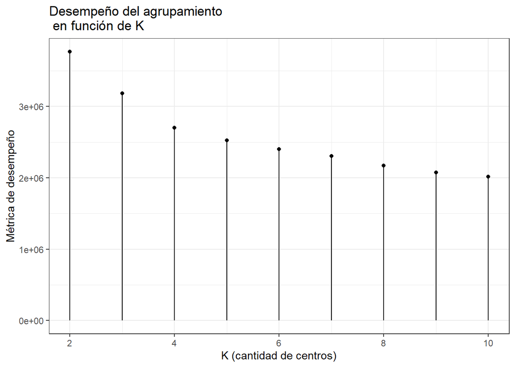

La gráfica anterior muestra que cuando se pasa de cuatro a cinco grupos la ganancia en la disminución de la métrica es mucho menor a la obtenida cuando se pasa de tres a cuatro grupos. Por lo tanto, buscando mantener el número más bajo de grupos con el mayor nivel de discriminación, se decide tener cuatro grupos.

Ahora se presentan las medias y las desviaciones estándar de cada grupo:

Medias

| grupo | estado_actual | acompanamiento | conciencia | planeacion | proteccion | relacion_con_el_dinero | soluciones |
| --- | --- | --- | --- | --- | --- | --- | --- |
| 1 | 18.47 | 18.19 | 32.45 | 31.54 | 27.46 | 35.87 | 10.91 |
| 2 | 48.56 | 43.55 | 57.49 | 61.19 | 40.83 | 46.52 | 18.75 |
| 3 | 43.68 | 43.93 | 49.96 | 57.65 | 41.34 | 47.57 | 95.10 |
| 4 | 76.38 | 73.55 | 75.53 | 84.58 | 70.28 | 49.69 | 94.99 |

Desviaciones estándar

| grupo | estado_actual | acompanamiento | conciencia | planeacion | proteccion | relacion_con_el_dinero | soluciones |
| --- | --- | --- | --- | --- | --- | --- | --- |
| 1 | 14.95 | 15.71 | 19.98 | 19.85 | 12.53 | 16.98 | 17.26 |
| 2 | 19.49 | 22.83 | 19.60 | 19.07 | 17.35 | 15.02 | 20.38 |
| 3 | 22.08 | 21.22 | 19.30 | 20.57 | 18.22 | 15.16 | 9.94 |
| 4 | 13.04 | 19.38 | 19.02 | 15.19 | 18.62 | 14.15 | 13.81 |

### Descripción de los grupos

- Grupo 1: estos usuarios tienen bajos puntajes en todas las dimensiones. Un nombre para describirlos podría ser usuarios con alto estrés financiero.
- Grupo 2: estos usuarios tienen puntuaciones medias en casi todas las dimensiones, excepto en la dimensión de soluciones. Podrían describirse como los que tienen un estrés financiero moderado y un bajo conocimiento de productos financieros.
- Grupo 3: como los usuarios del grupo 2, estos tienen un nivel de estrés financiero moderado. Sin embargo, tienen un alto conocimiento de productos financieros.
- Grupo 4: estos usuarios tienen puntajes altos en la mayoría de las dimensiones. Su puntaje de la relacion con el dinero es medio y con soluciones es alto. Estos usuarios podrían denominarse individuos con bajo estrés financiero y con altos conocimientos en finanzas.

### ¿Cómo se ven estos grupos?

A continuación se utiliza un gráfico de radar para representar los grupos usando sus valores medios en cada una de las dimensiones del test del bienestar financiero. Adicionalmente, se presentan el porcentaje de individuos en la muestra que caen en cada grupo y el valor promedio del score de buró de cada grupo. Para calcular el score de buró promedio se excluyen los individuos con un score igual a cero.

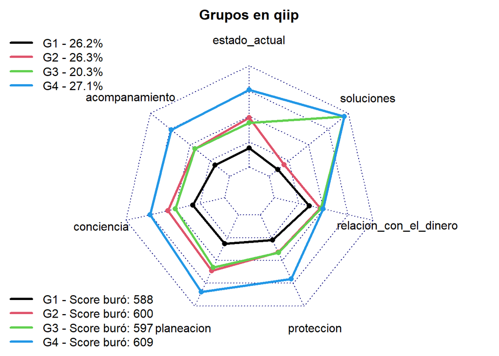

Ahora se presenta el boxplot del score de buró para cada grupo:

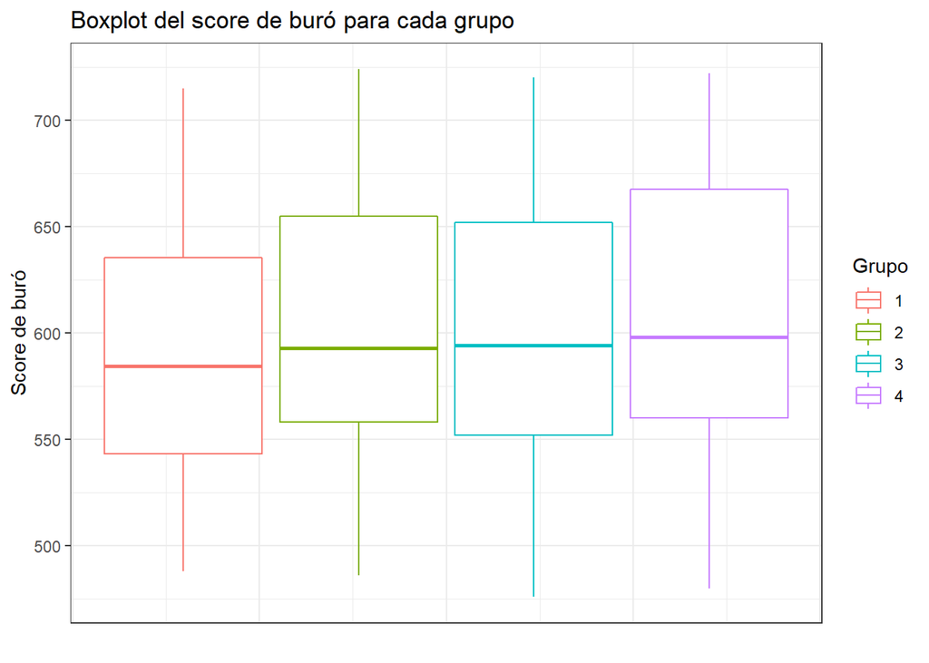

La figura anterior muestra que las diferencias entre los score de buró de los cuatro grupos no son significativas. Si bien los valores medianos de los grupos (la linea del medio de cada caja) están alineados con lo que intuitivamente se espera, no pareciera que el grupo fuera un factor determinante para predecir el score de buró.

## Conclusiones

El test de bienestar financiero permite identificar grupos de usuarios caracterizados por distintos niveles de estrés financiero y de conocimiento de soluciones.

Aunque las medianas del score de buró de los grupos están alineadas con lo que la intuición podría indicar, estos grupos no explican el score de buró.

Este último hecho puede deberse a que no se estén controlando variables como la edad, el sexo y el nivel de ingresos. Para explorar la relación entre el score de buró y el test de bienestar financiero se recomienda llevar a cabo nuevos análisis incluyendo nuevas variables.